# Lab4_25_26_Hugo_Garcia_Souto

### Answers:

**1. Can you find a number of levels to separate the foreground (global threshold)?** No. Due to uneven lighting (shadows), any global threshold fails. A low threshold misses digits in shadows, while a high threshold treats the bright background as noise.

**2. How do you rate the performance of Otsu's thresholding?** Poor. Otsu calculates a single global threshold. Since the histogram lacks two clearly separated peaks (foreground vs. background overlap), it cannot segment the image effectively.

**3. Does the GMM fit our needs here?** No. GMM relies on the assumption that foreground and background pixel intensities form distinct global distributions (mixtures of Gaussians). Due to the uneven lighting, the "background" intensity spans a wide range, overlapping with the "foreground" intensities. GMM fails to model this without local spatial context.

**4. Based on the results, what number of clusters would you choose and why?** Actually, none of the K-values provide good segmentation.

- **With $k=2$:** Uneven illumination causes the dark background in shadows to merge with the digits.
- **With $k \ge 3$:** K-means separates intensity bands (lighting gradients) rather than objects, mixing digits into these bands.

**5. How do these two methods (K-means and MeanShift) handle the problem?** Both fail to segment the sudoku grid correctly because they rely on global pixel intensity.

- **K-means:** Clusters based on absolute intensity, grouping dark shadows with black digits.
- **MeanShift:** Segments based on density modes. It tends to segment the image into bands of lighting gradients (shadow vs. light) rather than separating the semantic objects (digits) from the background, and it is computationally expensive.

**6. Argue what this type of adaptive thresholding actually does.** Adaptive thresholding calculates a threshold for each pixel based on a small local region (block size). It determines if a pixel is darker *relative to its neighbors* rather than the global average. This cancels out illumination gradients, allowing edge detection in both bright and dark areas.

**7. Suggest how you would proceed to segment the foreground.** The optimal pipeline is: **Gaussian Blur** (to reduce noise) $\rightarrow$ **Adaptive Thresholding** (to handle shadows) $\rightarrow$ **Morphological Operations** (Closing/Opening to refine lines).

**Exercise 9 (0.05 pts):** Read and visualize the image 'fieldWheat.png', and use k-means (**with number of clusters=3**) to segment:

1. The field of wheat alone. Save the resulting image.
2. The whole sky (clear sky and clouds)
- **Note 1:** If more than 1 feature (e.g. 'R', 'G', and 'B' in a color image) is given, each feature should be given as a column.
- **Note 2:** Remember that different initializations may lead to different clusters.

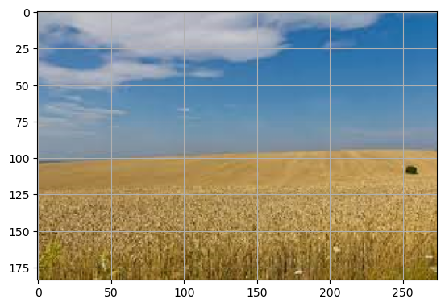

```python
img = cv2.imread(images_path + 'field.png')      # cv2 reads it BGR order
if img is None:
  sys.exit('Input image not found, check the path')

plt.imshow(img[...,::-1])
plt.show()
```

```python
X = np.array([img[:, :, 0].reshape(-1), img[:, :, 1].reshape(-1), img[:, :, 2].reshape(-1)]).T
print(X.shape)
```

```
(50416, 3)
```

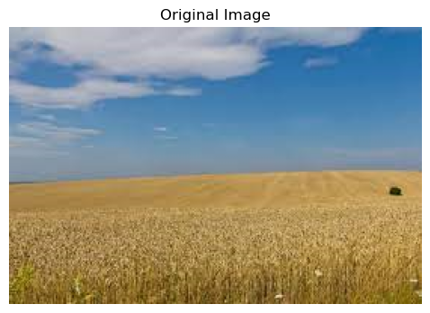

```
Data dimensions for clustering: (50416, 3)
```

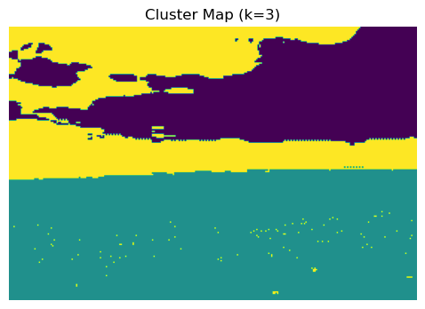

```
Cluster centers (RGB):
Cluster 0: [ 73 128 174]
Cluster 1: [165 133  71]
Cluster 2: [144 160 177]

Auto-detected Wheat Cluster: 1
```

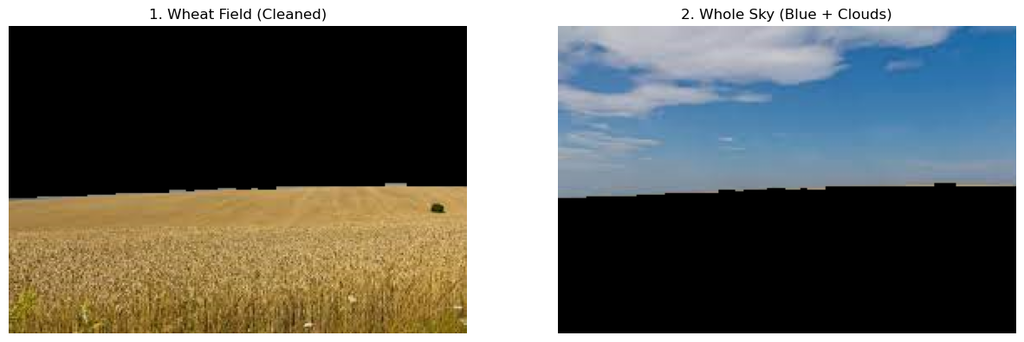

```python
#  - Apply K-means with k = 3 to the RGB pixels in X.
#  - Reshape the labels to the image shape and visualize the cluster map.
#  - Overlay the clustering result on the original image.
#  - Inspect the cluster centers and decide which cluster corresponds to:
#       - The wheat field
#       - The sky (clear sky + clouds)
#       - Any remaining region

if img is None:
    print("Error: Image not found (field.png or fieldWheat.png).")
else:
    # Convert from BGR to RGB
    img_rgb = cv2.cvtColor(img, cv2.COLOR_BGR2RGB)

    # Visualize original image
    plt.figure(figsize=(6, 4))
    plt.imshow(img_rgb)
    plt.title("Original Image")
    plt.axis('off')
    plt.show()

    # 2. Prepare data for K-means
    X = img_rgb.reshape(-1, 3)
    print(f"Data dimensions for clustering: {X.shape}")

    # 3. Apply K-means with k=3
    k = 3
    kmeans = KMeans(n_clusters=k, n_init="auto", random_state=42)
    kmeans.fit(X)

    labels = kmeans.labels_
    centers = kmeans.cluster_centers_

    # 4. Reconstruct the label image
    segmented_labels = labels.reshape(img_rgb.shape[:2])

    # Visualize the cluster map
    plt.figure(figsize=(6, 4))
    plt.imshow(segmented_labels, cmap='viridis')
    plt.title(f"Cluster Map (k={k})")
    plt.axis('off')
    plt.show()

    # Determine clusters automatically (Heuristic based on Red/Blue dominance)
    wheat_cluster_idx = -1
    max_red_dominance = -np.inf

    print("Cluster centers (RGB):")
    for i, c in enumerate(centers):
        print(f"Cluster {i}: {c.astype(int)}")
        # Wheat (Yellow/Gold) has high Red and Green, low Blue. Sky has high Blue.
        # We find the cluster where (Red - Blue) is maximized.
        r, g, b = c
        if (r - b) > max_red_dominance:
            max_red_dominance = (r - b)
            wheat_cluster_idx = i

    print(f"\nAuto-detected Wheat Cluster: {wheat_cluster_idx}")

    # ---------------------------------------------------------
    # IMPROVEMENT: Morphological Cleaning
    # ---------------------------------------------------------
    # Initial masks
    mask_wheat = (segmented_labels == wheat_cluster_idx).astype(np.uint8)
    mask_sky_complete = 1 - mask_wheat # Everything else is sky/clouds

    # Define a kernel (5x5 square)
    kernel = np.ones((5,5), np.uint8)

    # Apply OPENING to Sky mask: Removes small white spots (wheat tips) from the sky mask
    # Logic: If a "cloud" is as small as a wheat tip, remove it.
    mask_sky_complete = cv2.morphologyEx(mask_sky_complete, cv2.MORPH_OPEN, kernel)

    # Update Wheat mask to fill the gaps we just created
    mask_wheat = 1 - mask_sky_complete

    # 5. Visualization and Saving
    plt.figure(figsize=(15, 5))

    # --- Wheat Field ---
    wheat_img = cv2.bitwise_and(img_rgb, img_rgb, mask=mask_wheat)
    plt.subplot(1, 2, 1)
    plt.imshow(wheat_img)
    plt.title("1. Wheat Field (Cleaned)")
    plt.axis('off')

    # Save result
    cv2.imwrite('wheat_field_segmented.png', cv2.cvtColor(wheat_img, cv2.COLOR_RGB2BGR))

    # --- Whole Sky ---
    whole_sky_img = cv2.bitwise_and(img_rgb, img_rgb, mask=mask_sky_complete)
    plt.subplot(1, 2, 2)
    plt.imshow(whole_sky_img)
    plt.title("2. Whole Sky (Blue + Clouds)")
    plt.axis('off')

    plt.show()
```

**Exercise 10 (0.15 pts): Density-based clustering**